# Master en Big Data. Fundamentos Matemáticos del Análisis de Datos (FMAD).

Tarea 2

Carlos García Vázquez

Curso 2021-22. Última actualización: 2021-09-24

# Instrucciones preliminares

- Empieza abriendo el proyecto de RStudio correspondiente a tu repositorio personal de la asignatura.
- En todas las tareas tendrás que repetir un proceso como el descrito en la sección *Repite los pasos Creando un fichero Rmarkdown para esta práctica* de la *Práctica00*. Puedes releer la sección *Practicando la entrega de las Tareas* de esa misma práctica para recordar el procedimiento de entrega.

# Preliminares

Carga de librerías inicial:

```r
library(tidyverse)
```

# Ejercicio 1. Simulando variables aleatorias discretas.

**Apartado 1:** La variable aleatoria discreta $X1$ tiene esta tabla de densidad de probabilidad (es la variable que se usa como ejemplo en la Sesión ):
$$\begin{array}{|c|c|c|c|c|c|c|}
\hline
\text{valor de }X1 & 0 & 1 & 2 & 3 \\
\hline
\text{Probabilidad de ese valor }P(X = x_i) & \dfrac{64}{125} &
\dfrac{48}{125}& \dfrac{12}{125} & \dfrac{1}{125}\rule{0mm}{6mm} \\[3mm]
\hline
\end{array}$$

Creamos los vectores para trabajar con ellos.

```r
X1=c(0:3)
pX1=c(64/125,48/125,12/125,1/125)
(tableX1=data.frame(X1,pX1))
```

```
##   X1   pX1
## 1  0 0.512
## 2  1 0.384
## 3  2 0.096
## 4  3 0.008
```

Calcula la media y la varianza teóricas de esta variable.

```r
#Media teórica
(mu_t=sum(X1*pX1))
```

```
## [1] 0.6
```

```r
#Varianza teórica
(var_t=sum(((X1-mu_t)^2)*pX1))
```

```
## [1] 0.48
```

**Apartado 2:** Combina `sample` con `replicate` para simular cien mil muestras de tamaño 10 de esta variable $X1$. Estudia la distribución de las medias muestrales como hemos hecho en ejemplos previos, ilustrando con gráficas la distribución de esas medias muestrales. Cambia después el tamaño de la muestra a 30 y repite el análisis.

Estudiaremos la distribución de las medias muestrales en 2 casos, entre los cuales, la principal diferencia será el tamaño de la muestra (n) empleado.

Número de muestras para ambos casos (k=100000)

```r
set.seed(2021)
k=100000
```

ANÁLISIS 1 (n=10)

1. Creamos el vector con las medias muestrales de las 100000 muestras generadas

```r
n1=10
mediasMuestrales1 = replicate(k, {
  muestra = sample(X1, n1, replace = TRUE,prob=pX1)
  mean(muestra)
})
```

2. Estudio de la distribución de las medias muestrales

A continuación, podemos apreciar la representación gráfica de la distribución de las medias muestrales

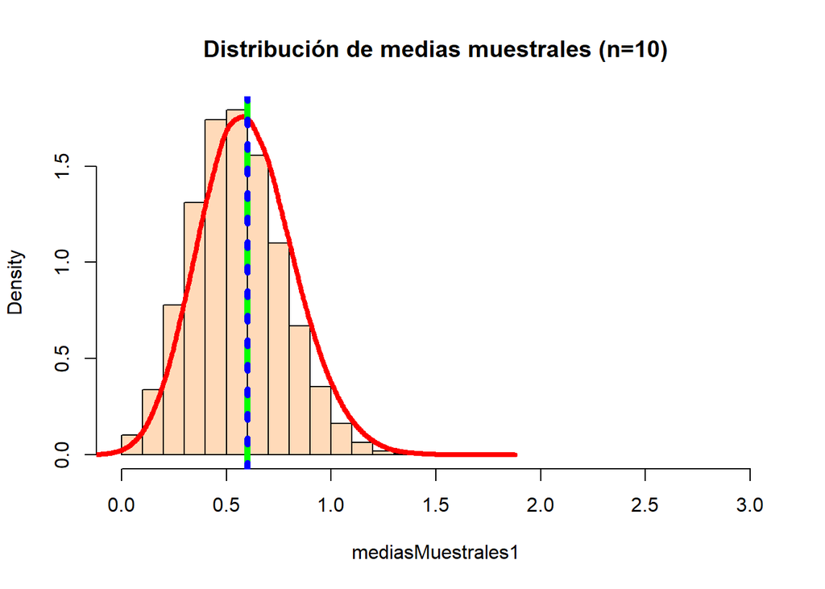

```r
hist(mediasMuestrales1, breaks = 20, main="Distribución de medias muestrales (n=10)",
     col="peachpuff", probability = TRUE, xlim=range(X1))
lines(density(mediasMuestrales1,adjust=3), lwd=4, col="red")
abline(v = mean(mediasMuestrales1), lty=2, lwd=5, col="green")
abline(v = mu_t, lty=3, lwd=5, col="blue")
```

En cuanto a la distribución, en primer lugar se puede apreciar que es asimétrica a la derecha. Aparte, las líneas discontinuas en color verde y azul ubicadas en el gráfico, representan las media obtenida a partir de las muestras tomadas y la media teórica, respectivamente. En este aspecto, destacar el hecho de que estos 2 valores coinciden, por lo que se podría decir que a partir de las 100000 muestras de tamaño 1o tomadas, se ha conseguido una buena estimación de la media teórica de la población.

Ahora, lo que vamos a hacer es aumentar el tamaño de las muestras tomadas.

ANÁLISIS 2 (n=30)

1. Creamos el vector con las medias muestrales de las 100000 muestras generadas

```r
n2=30
mediasMuestrales2 = replicate(k, {
  muestra = sample(X1, n2, replace = TRUE,prob=pX1)
  mean(muestra)
})
```

2. Estudio de la distribución de las medias muestrales

Representación gráfica de la distribución de las medias muestrales

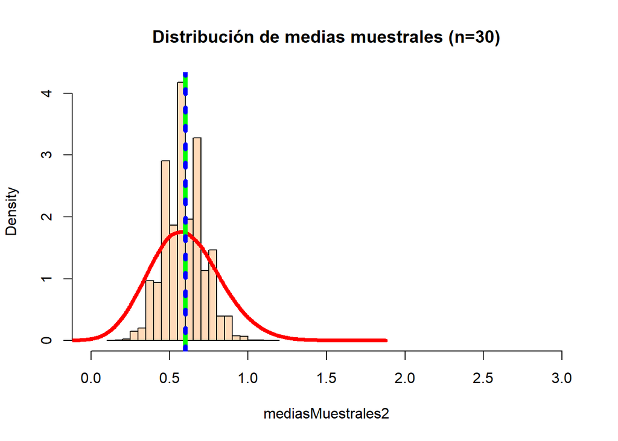

```r
hist(mediasMuestrales2, breaks = 20, main="Distribución de medias muestrales (n=30)",
     col="peachpuff", probability = TRUE, xlim=range(X1))
lines(density(mediasMuestrales1,adjust=3), lwd=4, col="red")
abline(v = mean(mediasMuestrales2), lty=2, lwd=5, col="green")
abline(v = mu_t, lty=3, lwd=5, col="blue")
```

Aquí, al igual que en el caso anterior, se aprecia la asimetría a la derecha, y la media obtenida a partir de las muestras y la teórica, que tambien coinciden en el gráfico.

CONCLUSIÓN

En ambos casos, hemos visto que la media de las medias muestrales coincide con la media de la población.

Aparte, se confirma lo que dice el conocido como Teorema Central del Límite, que afirma, que dado un tamaño de muestra aleatoria de la población lo suficientemente grande, la distribución de las medias muestrales seguirá una distribución normal, tal y como hemos podido comprobar en ambos casos.

Otra de las cosas a destacar en la comparación entre ambos gráficos, es la reducción de la anchura de la campana entorno a la media, al aumentar el tamaño de las muestras de 10 a 30. Por lo que la variabilidad en cuanto a las medias de las muestras disminuye, cumpliendo tambien con las afirmaciones del Teorema Central del Límite. En términos generales, a mayor tamaño de muestra, la precisión con la que obtenemos la media será mayor.

**Apartado 3:** La variable aleatoria discreta $X2$ tiene esta tabla de densidad de probabilidad:
$$\begin{array}{|c|c|c|c|c|c|}
\hline
\text{valor de }X2 & 0 & 1 & 2 \\
\hline
\text{Probabilidad de ese valor }P(X = x_i) & \dfrac{1}{2} &
\dfrac{1}{4}& \dfrac{1}{4}\rule{0mm}{6mm} \\[3mm]
\hline
\end{array}$$
Suponemos que $X1$ y $X2$ son independientes. ¿Qué valores puede tomar la suma $X1 + X2$? ¿Cuál es su tabla de probabilidad?

Nuestra variable a estudiar es $X1 + X2$

Tabla de probabilidades de $X2$

```r
X2=c(0:2)
pX2=c(1/2,1/4,1/4)
(tableX2=data.frame(X2,pX2))
```

```
##   X2  pX2
## 1  0 0.50
## 2  1 0.25
## 3  2 0.25
```

```r
#Media teórica
(mu_t1=sum(X2*pX2))
```

```
## [1] 0.75
```

```r
#Varianza teórica
(var_t1=sum(((X2-mu_t1)^2)*pX2))
```

```
## [1] 0.6875
```

A continuación, vamos a crear una tabla con las distintas posibilidades que se pueden dar entre ambos conjuntos de datos, cuanto sería la suma entre ambos y la probabilidad de que sucedan, teniendo en cuenta las tablas de probabilidad de ambas variables.

Al ser variables independientes X1 y X2, la intersección de los sucesos se calcula como la multiplicación de las probabilidades de cada uno.

```r
pos=merge(tableX1$X1,tableX2$X2) %>%
  mutate(posSum=x+y,prob=rep(tableX1$pX1,times=3)*rep(tableX2$pX2,each=4))
rename(pos,X1=x,X2=y)
```

```
##    X1 X2 posSum  prob
## 1   0  0      0 0.256
## 2   1  0      1 0.192
## 3   2  0      2 0.048
## 4   3  0      3 0.004
## 5   0  1      1 0.128
## 6   1  1      2 0.096
## 7   2  1      3 0.024
## 8   3  1      4 0.002
## 9   0  2      2 0.128
## 10  1  2      3 0.096
## 11  2  2      4 0.024
## 12  3  2      5 0.002
```

Convertimos la columna ‘posSum’ en factor para hacer la clasificación y agrupar por cada resultado posible

```r
pos$posSum=as.factor(pos$posSum)
```

Realizamos el cálculo final de la tabla de probabilidades de la nueva variable X1 + X2

```r
pos %>%
  group_by(posSum) %>%
  summarise(prob=sum(prob))
```

```
## # A tibble: 6 x 2
##   posSum  prob
##   <fct>  <dbl>
## 1 0      0.256
## 2 1      0.32
## 3 2      0.272
## 4 3      0.124
## 5 4      0.026
## 6 5      0.002
```

**Apartado 4:** Calcula la media teórica de la suma $X_1 + X_2$. Después usa `sample` y `replicate` para simular cien mil *valores* de esta variable suma. Calcula la media de esos valores. *Advertencia:* no es el mismo tipo de análisis que hemos hecho en el segundo apartado.

Cálculo de la media teórica de la variable X1+X2

1. Cálculo a partir de los resultados obtenidos en el apartado anterior

Tener en cuenta que con el as.numeric y la función paste, conseguimos transformar los valores reales de la columna posSum del DataFrame pos de tipo factor a numérico.

```r
#Media teórica
(mu_t2=sum(as.numeric(paste(pos$posSum))*pos$prob))
```

```
## [1] 1.35
```

2. Cálculo a partir de las medias de cada variable

La media de la suma es la suma de las medias

$E(X_1 + X_2) = E(X_1) + E(X_2)$

```r
(mu_suma=mu_t+mu_t1)
```

```
## [1] 1.35
```

Hemos calculado la media teórica de las 2 formas, y como era evidente el resultado es el mismo.

En este caso, cogemos k=100000 muestras de tamaño 1 cada una de ambas variables para estudiar la suma de las mismas

```r
set.seed(2021)
k=100000
n3=1
```

Calculamos las medias muestrales de la variable X1+X2, sabiendo que su media será igual a la suma de la media de X1 más la media de X2:

```r
mediasMuestrales3 = replicate(k, {
  muestraX1 = sample(X1, n3, replace = TRUE,prob=pX1)
  muestraX2 = sample(X2, n3, replace = TRUE,prob=pX2)
  muestraX1 + muestraX2
})
```

La media de estos valores es:

```r
(mediaFinal=mean(mediasMuestrales3))
```

```
## [1] 1.35143
```

Podemos ver que sale igual, a excepción de algunos decimales, que la media teórica calculada previamente en el apartado anterior.

En este caso hemos reducido el tamaño de la muestra lo máximo hasta tomar una única, haciendo que la variabilidad de las medias obtenidas en las muestras sea mayor, y reduciendo de esta forma la precisión en cuanto a la estimación de la media con respecto a la teórica.

# Ejercicio 2. Datos limpios

- Descarga el fichero de este enlace

https://gist.githubusercontent.com/fernandosansegundo/471b4887737cfcec7e9cf28631f2e21e/raw/b3944599d02df494f5903740db5acac9da35bc6f/testResults.csv

Una vez descargado el fichero, lo cargamos, vemos su estructura y como está organizado

```r
testResults=read_csv("./data/testResults.csv")
head(testResults)
```

```
## # A tibble: 6 x 9
##   name       id gender_age test_number week1 week2 week3 week4 week5
##   <chr>   <dbl> <chr>            <dbl> <dbl> <dbl> <dbl> <dbl> <dbl>
## 1 Jacob     108 m_20                 1     8     5     7     5     6
## 2 Jacob     108 m_20                 2     2     2     4     0     3
## 3 Michael   490 m_19                 1    10     0     5     4     0
## 4 Michael   490 m_19                 2     9    10     8    10     9
## 5 Matthew   424 m_18                 1     6     0     0     1    10
## 6 Matthew   424 m_18                 2     3     4     2     5     8
```

```r
names(testResults)
```

```
## [1] "name"        "id"          "gender_age"  "test_number" "week1"
## [6] "week2"       "week3"       "week4"       "week5"
```

- Este fichero contiene las notas de los alumnos de una clase, que hicieron dos tests cada semana durante cinco semanas. La tabla de datos no cumple los principios de *tidy data* que hemos visto en clase. Tu tarea en este ejercicio es explicar por qué no se cumplen y obtener una tabla de datos limpios con la misma información usando *tidyR*.  
  **Indicación:** lee la ayuda de la función `separate` de *tidyR*.
1. Explicación de por qué no cumple con los principios de tidy data

Este conjunto de datos que se está estudiando, no es limpio, porque las filas no corresponden con observaciones y las columnas no corresponden con variables, que son precisamente 2 de las 3 condiciones para que un conjunto de datos se considere limpio.

2. Obtención de tabla de datos limpios con la misma información

Primero, hay que convertir los valores de semana en una columna, lo que hará la tabla más larga y estrecha. Todo esto haciendo uso de la funcion ‘pivot_longer()’

Luego, separamos la variable gender_age en las variables gender y age correspondientes, haciendo uso de la funcion separate()

Separamos la columna week para quedarnos con el valor numérico que identifica a cada una de las semanas, y borramos la columna en la que se queda el valor repetido ‘week’

Para terminar y dejar el DataFrame limpio, pasamos la columna week de tipo ‘character’ a numérica. Aunque luego, en función del estudio que se pretenda realizar sobre el conjunto de datos en cuestión, se podrá cambiar el tipo de variable, según interese.

```r
ResultsTidy = testResults %>%
pivot_longer(week1:week5, names_to = "week") %>%
  separate(gender_age,c("gender","age"),sep="_") %>%
  separate(week,c('w','week'),sep=4)%>%
  mutate(w=NULL)
ResultsTidy$week=as.numeric(ResultsTidy$week)
ResultsTidy
```

```
## # A tibble: 1,000 x 7
##    name     id gender age   test_number  week value
##    <chr> <dbl> <chr>  <chr>       <dbl> <dbl> <dbl>
##  1 Jacob   108 m      20              1     1     8
##  2 Jacob   108 m      20              1     2     5
##  3 Jacob   108 m      20              1     3     7
##  4 Jacob   108 m      20              1     4     5
##  5 Jacob   108 m      20              1     5     6
##  6 Jacob   108 m      20              2     1     2
##  7 Jacob   108 m      20              2     2     2
##  8 Jacob   108 m      20              2     3     4
##  9 Jacob   108 m      20              2     4     0
## 10 Jacob   108 m      20              2     5     3
## # ... with 990 more rows
```